# Exploratory Data Analysis: Education, Poverty, Unemployment, and Voting Patterns

Adu-Gyamfi Kelly

2025-09-24

# 1 Objective Statement & Background

This exploratory data analysis examines the relationship between educational attainment, unemployment rates, poverty levels, and political voting patterns across US counties. The objective is to identify potential correlations between socioeconomic factors and political outcomes, which could inform further research into the determinants of voting behavior at the county level. The dataset contains county-level information from the United States, including educational attainment statistics, unemployment rates, poverty percentages, and 2020 presidential election results.

# 2 Data Set Description

- **Source**: Compiled from US Census Bureau data and election results
- **Collection Method**: Government statistical reports and official election records
- **Size**: Contains data for multiple counties across states
- **Variables**: 15 variables mixing categorical and numerical types

## 2.1 Variable Definitions

- **COUNTY_FIPS**: Unique county identifier code
- **State**: Two-letter state abbreviation
- **Area_name**: County or region name
- **LESS_THAN_HS**: Count of population with less than high school education
- **HS_ONLY**: Count with high school diploma only
- **SOME_COLLEGE_15_19**: Count with some college education
- **BACHELORS_15_19**: Count with bachelor’s degree or higher
- **PCT_LESS_THAN_HS_15_19**: Percentage with less than high school education
- **PCT_HS_ONLY_15_19**: Percentage with high school diploma only
- **PCT_SOME_COLLEGE_15_19**: Percentage with some college education
- **PCT_BAC_0R_HIGH_15_19**: Percentage with bachelor’s degree or higher
- **WINNING_PARTY**: Political party that won the county (REPUBLICAN/DEMOCRAT)
- **TOTAL_VOTES**: Total votes cast in the county
- **UNWMPLOYMENT_RATE**: County unemployment rate
- **PCTPOVALL_2019**: Percentage of population living in poverty

# 3 Exploratory Data Analysis

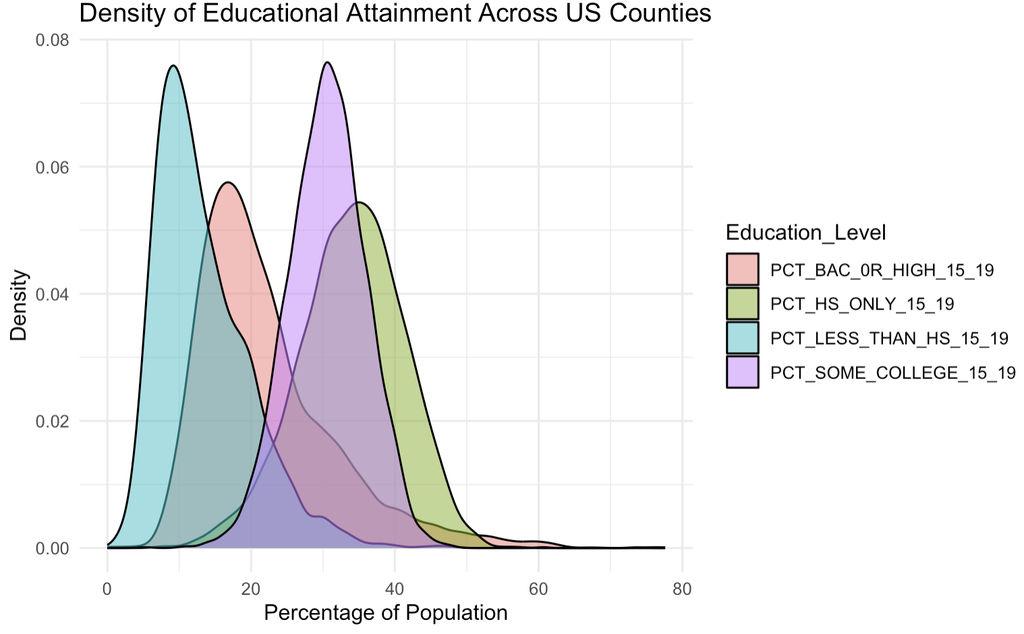

# 4 Relationship Between Education and Poverty

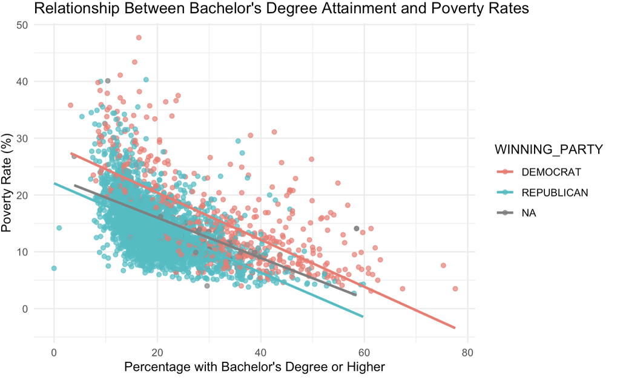

**Interpretation**: This scatterplot reveals a negative correlation between the percentage of population with bachelor’s degrees and poverty rates. Counties with higher educational attainment tend to have lower poverty rates. The coloring by winning political party suggests potential patterns in how these factors relate to voting behavior

# 5 Unemployment by Political Affiliation

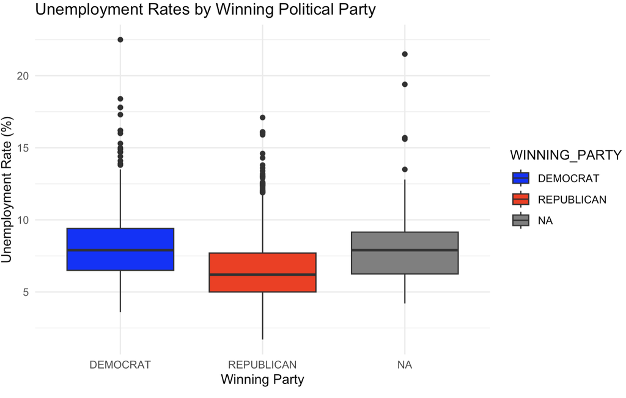

**Interpretation**: The boxplot compares unemployment rates between counties that voted Republican versus Democratic. Preliminary analysis suggests differences in economic conditions between counties favoring different parties, which warrants further investigation.

# 6 Pairwise Relationship Between Numeical Variables

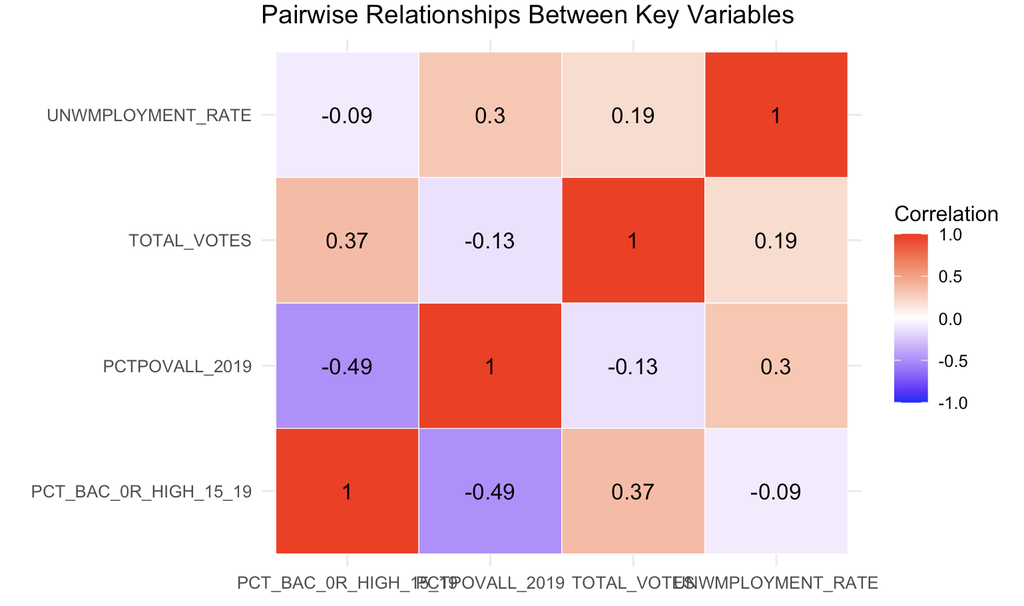

# 7 Interpretation

**Education vs Poverty (-0.49)** : This is a moderate negative correlation. It means that as the percentage of the population with a bachelor’s degree or higher increases, the poverty rate tends to decrease. This is one of the most consistent findings in social science and is clearly visible in this data. Higher educational attainment is associated with lower levels of poverty.

**Poverty vs. Unemployment (0.30)**: There is a weak positive correlation. As expected, areas with higher poverty rates tend to have slightly higher unemployment rates, though the relationship is not extremely strong.

**Unemployment vs. Total Votes (0.19)**: A very weak positive correlation, suggesting a minimal relationship between unemployment and the number of votes cast.

**Education vs. Unemployment (-0.09)**: The correlation is very close to zero, indicating almost no linear relationship between the educational attainment level in an area and its unemployment rate in this particular dataset. This is a interesting finding, as it might be counterintuitive.

# 8 Results & Discussion

These findings raise additional research questions worthy of investigation:

- Does the relationship between education and voting behavior hold when controlling for other factors?
- How do regional differences (e.g., urban vs. rural) mediate these relationships?
- What causal mechanisms might explain the correlation between education levels and political outcomes?